# ASSIGNMENT 2 - RR course - R Markdown

Sang Luong

06/04/2022

### 1.Description of the show

*How I Met Your Mother* (often abbreviated as HIMYM) is an American sitcom, created by Craig Thomas and Carter Bays for CBS. The series, which aired from 2005 to 2014, follows the main character, Ted Mosby, and his group of friends in New York City’s Manhattan. As a framing device, Ted, in the year 2030, recounts to his son, Luke, and daughter, Penny, the events from September 2005 to May 2013 that led him to meet their mother. How I Met Your Mother is a joint production by Bays & Thomas Productions and 20th Television and syndicated by 20th Television (now Disney-ABC Domestic Television).

The series was loosely inspired by Thomas and Bays’ friendship when they both lived in Chicago. The vast majority of episodes were directed by Pamela Fryman, who directed 196 episodes out of 208. The other directors were Rob Greenberg (7 episodes), Michael Shea (4 episodes), and Neil Patrick Harris (1 episode).

Known for its unique structure, humor, and incorporation of dramatic elements, How I Met Your Mother was popular throughout its run. The show was nominated for 91 awards and received 21. In 2010, Alyson Hannigan won the People’s Choice Award for Favorite TV Comedy Actress. In 2012, seven years after its premiere, the series won the People’s Choice Award for Favorite Network TV Comedy, and Neil Patrick Harris won the award for Favorite TV Comedy Actor twice.

[figure not shown]

How I met your mother poster

### 2.Ratings and Adwards

*1. Ratings*

The show’s highest viewed episode was the series finale, “Last Forever”, watched by 13.13 million viewers. Previously, the most viewed episode was the season 1 episode “The Pineapple Incident”, watched by 12.3 million viewers. The lowest-viewed episode was the season 6 episode “Landmarks”, watched by 6.4 million viewers, approximately 52% of the show’s previous series high, and approximately 49% of the show’s finale viewership.

### 3.Ratings Plots

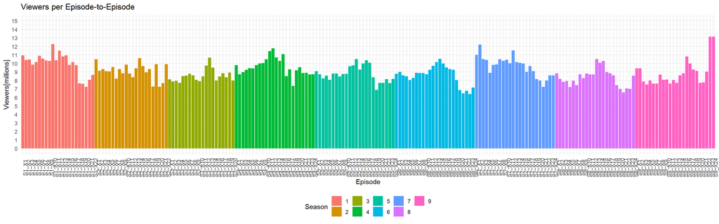

### 4.Description data

In general, How I met your mother is on of the most successful American sitcom with average 9.0442308 millions spectators (+/- 0.0849027) per episode.